# Field Code state to state network graph

We are going to work with a network graph that shows the level of state to state borrowings of codes of civil procedure in the nineteenth century. Notice that the data for code-to-code borrowings are also available in this repository.

## Loading the data and creating the graph

Networks are defined by a data frame of edges and (optionally) a data frame of nodes. An edge table has two columns of node names showing a connection between them. A node table has one column of node names. Optionally, both can include additional columns of metadata specific to nodes or edges.

```r
edges_df <-read_csv("field-states-edges.csv")
nodes_df <-read_csv("field-states-nodes.csv")
```

We can turn those data frames into a graph (the mathematical term for a network).

```r
g <- graph_from_data_frame(edges_df, directed = TRUE, vertices = nodes_df)
g <- g %>% as_tbl_graph()
g
```

```
## # A tbl_graph: 36 nodes and 48 edges
## #
## # A directed simple graph with 3 components
## #
## # Node Data: 36 x 2 (active)
##   name  region
##   <chr> <chr>
## 1 AK    West
## 2 AR    South
## 3 AZ    West
## 4 CA    West
## 5 CO    West
## 6 DC    South
## # ... with 30 more rows
## #
## # Edge Data: 48 x 3
##    from    to sections_borrowed
##   <int> <int>             <int>
## 1     1    23               709
## 2     2    31               774
## 3     2    14               107
## # ... with 45 more rows
```

We can get a quick look at the graph using `plot()`

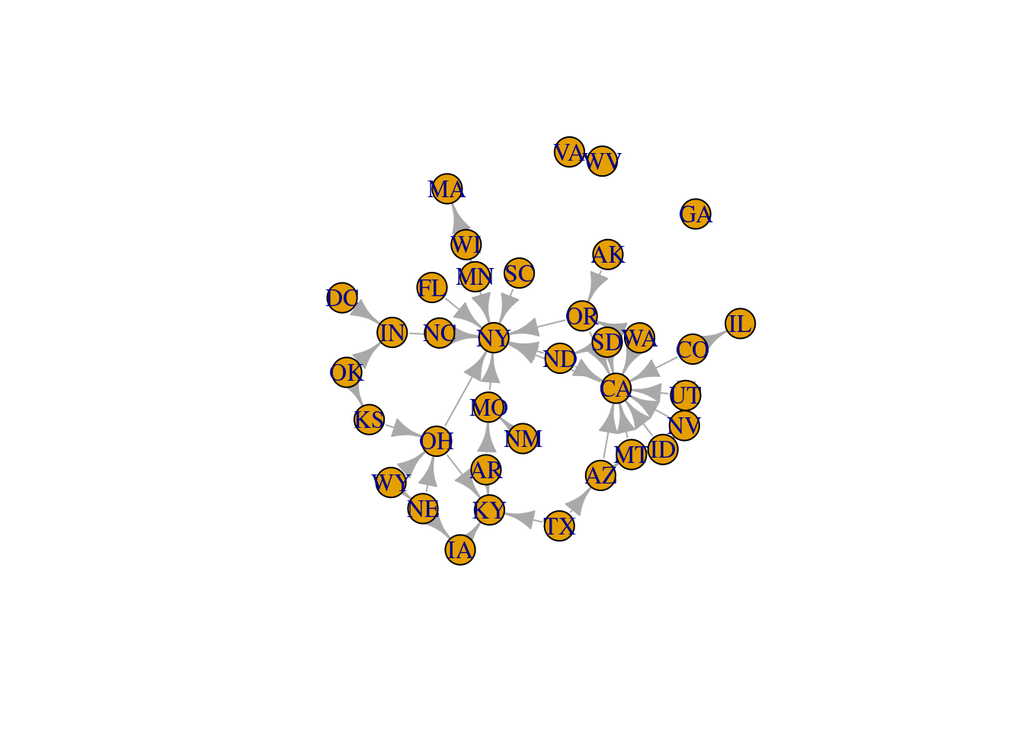

```r
plot(g)
```

## Measuring the centrality of nodes

The importance, called *centrality*, of a node can be measured with various algorithms. These can be added to the graph object as node attributes using `mutate()`. Note that below we pull out the nodes data frame to inspect it and do not save the results back to our graph object `g` just yet.

Look at the definitions given in *The Historian’s Macroscope* and follow the links to the documentation for the various functions using `?centrality`. Also use your intution from the visualization of the graph above. What measure of centrality is most appropriate for this graph?

```r
centrality <- g %>%
  mutate(c_authority = centrality_authority() %>% round(4),
         c_betweenness = centrality_betweenness() %>% round(4),
         c_closeness = centrality_closeness() %>% round(4),
         c_eigen = centrality_eigen() %>% round(4),
         c_hub = centrality_hub() %>% round(4),
         c_pagerank = centrality_pagerank() %>% round(4),
         c_communicability = centrality_communicability() %>% round(4)) %>%
  as_data_frame(what = "vertices")
centrality
```

```
##    name      region c_authority c_betweenness c_closeness c_eigen  c_hub
## AK   AK        West      0.0000           0.0       9e-04  0.1124 0.0425
## AR   AR       South      0.0000           0.0       9e-04  0.0694 0.0652
## AZ   AZ        West      0.0094           5.0       9e-04  0.3293 0.5082
## CA   CA        West      0.8841           8.0       8e-04  1.0000 0.5308
## CO   CO        West      0.0000           0.0       9e-04  0.2342 0.5082
## DC   DC       South      0.0000           0.0       8e-04  0.0460 0.0000
## SD   SD        West      0.0000           0.0       9e-04  0.3291 0.5082
## FL   FL       South      0.0000           0.0       8e-04  0.1829 0.5308
## IA   IA     Midwest      0.0000           0.5       8e-04  0.0416 0.0598
## ID   ID        West      0.0734           3.0       9e-04  0.3920 0.5542
## IN   IN     Midwest      0.0000           2.0       8e-04  0.2069 0.5308
## KS   KS        West      0.0000           2.0       9e-04  0.0710 0.0000
## MN   MN     Midwest      0.0000           0.0       9e-04  0.2381 0.5748
## MO   MO     Midwest      0.0102           2.0       8e-04  0.2087 0.5308
## MT   MT        West      0.0734           4.0       9e-04  0.3831 0.5082
## NC   NC       South      0.0000           0.0       8e-04  0.1829 0.5308
## ND   ND        West      0.0734           0.5       8e-04  0.4787 1.0000
## NE   NE        West      0.0000           1.0       9e-04  0.0833 0.0000
## NM   NM        West      0.0000           0.0       8e-04  0.0464 0.0054
## NV   NV        West      0.1601           0.0       8e-04  0.3781 0.4692
## OH   OH     Midwest      0.0000           6.5       8e-04  0.2571 0.5906
## OK   OK        West      0.0000           0.0       9e-04  0.0618 0.0000
## OR   OR        West      0.0800           2.5       8e-04  0.5050 1.0000
## SC   SC       South      0.0000           0.0       8e-04  0.1829 0.5308
## TX   TX       South      0.0000           0.0       1e-03  0.0963 0.0648
## UT   UT        West      0.0000           0.0       9e-04  0.3067 0.5542
## WA   WA        West      0.0000           0.0       9e-04  0.3350 0.5117
## WI   WI     Midwest      0.0830           1.0       8e-04  0.2482 0.5748
## WV   WV       South      0.0000           0.0       8e-04  0.0000 0.0000
## WY   WY        West      0.0000           0.0       9e-04  0.0758 0.0000
## KY   KY     Midwest      0.1127           0.0       8e-04  0.1034 0.0000
## NY   NY    New York      1.0000           0.0       8e-04  0.8216 0.0000
## IL   IL     Midwest      0.0734           0.0       8e-04  0.0521 0.0000
## MA   MA New England      0.0830           0.0       8e-04  0.0552 0.0000
## VA   VA       South      0.0000           0.0       8e-04  0.0000 0.0000
## GA   GA       South      0.0000           0.0       8e-04  0.0000 0.0000
##    c_pagerank c_communicability
## AK     0.0114            2.0000
## AR     0.0114            2.0000
```

[output cut: 19 more lines]

```
## OK     0.0114            6.0000
## OR     0.0260            0.0000
## SC     0.0114            1.0000
## TX     0.0114            6.0000
## UT     0.0114            1.0000
## WA     0.0114            2.0000
## WI     0.0163            0.0000
## WV     0.0761            2.7183
## WY     0.0114            6.0000
## KY     0.0525            0.0000
## NY     0.2088            0.0000
## IL     0.0163            0.0000
## MA     0.0183            0.0000
## VA     0.0761            2.7183
## GA     0.0114            1.0000
```

## Plotting

Networks can be plotted within the ggplot2 framework using the ggraph package. You will need to include geoms for both edges (`geom_edge_*`) and nodes (`geom_node_*`)

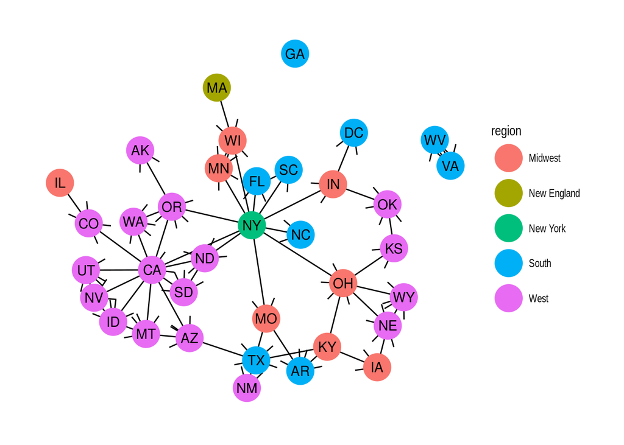

```r
ggraph(g, layout = "nicely") +
  geom_edge_fan(arrow = arrow(ends = "first")) +
  geom_node_point(aes(color = region), size = 10) +
  geom_node_text(aes(label = name)) +
  theme_graph()
```

## Clustering

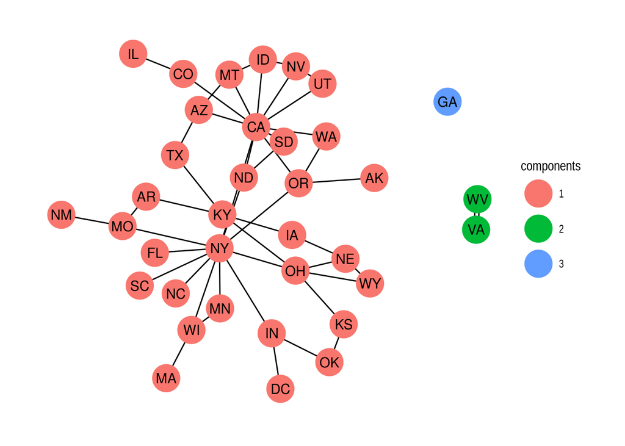

```r
groups <- g %>%
  mutate(infomap = as.factor(group_infomap()),
         walktrap = as.factor(group_walktrap()),
         components = as.factor(group_components()),
         betweenness = as.factor(group_edge_betweenness()))

ggraph(groups, layout = "nicely") +
  geom_edge_fan() +
  geom_node_point(aes(color = components), size = 10) +
  geom_node_text(aes(label = name)) +
  theme_graph()
```

## Node-pair level measures

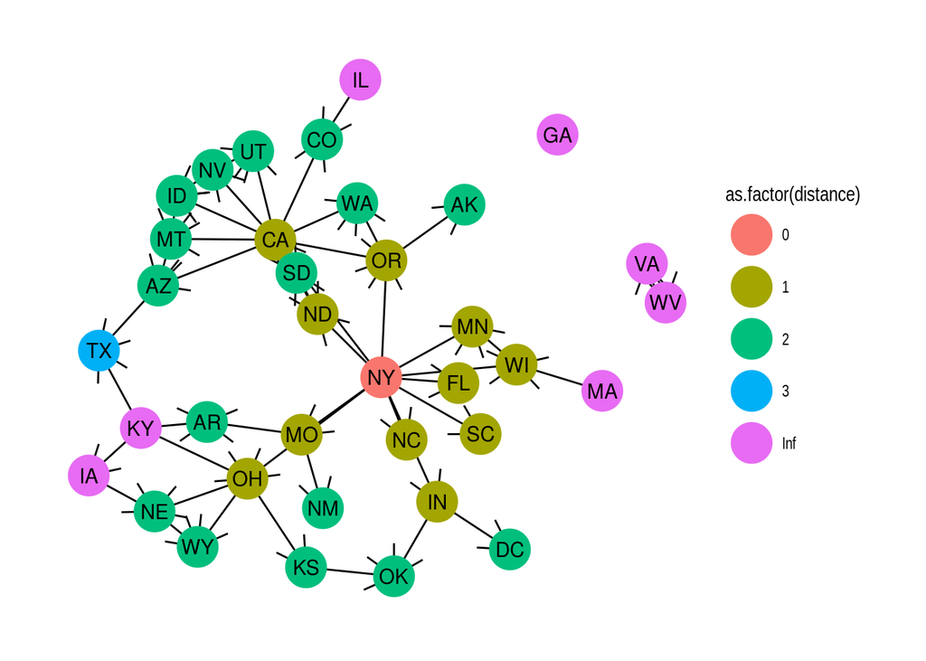

```r
distances <- g %>%
  mutate(is_ny = name == "NY",
         distance = node_distance_from(is_ny, mode = "in"))

ggraph(distances, layout = "nicely") +
  geom_edge_fan(arrow = arrow(ends = "first")) +
  geom_node_point(aes(color = as.factor(distance)), size = 10) +
  geom_node_text(aes(label = name)) +
  theme_graph()
```

## Component graphs

Sometimes parts of a graph are unconnected to other graphs, and it would be nice to pull them out into separate pieces.

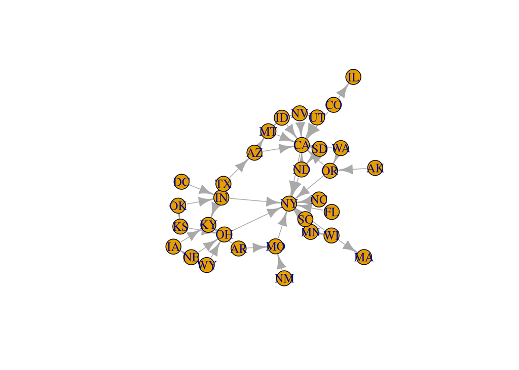

```r
components <- g %>% to_components()

plot(components[[1]])
```

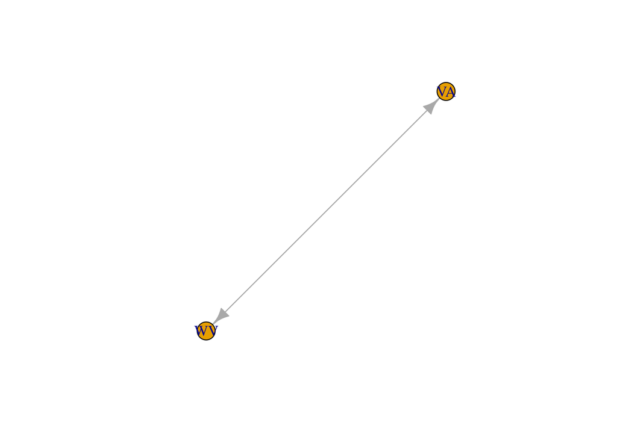

```r
plot(components[[2]])
```

```r
plot(components[[3]])
```

[output not shown]

## Bipartite graphs

A bipartite graph is a graph where the nodes fall into two different groups, and where members of a group are never connected to one another. A common example is a membership graph, with organizations and members. We can load a membership graph for revolutionary organizations in Boston.

```r
revere_edges <-read_csv("paul-revere-edges.csv")
revere_bip <- graph_from_data_frame(revere_edges)
```

Now that we have the graph loaded we can project it. We have to distinguish between the `type` of the nodes—which belong to which side of the projection.

```r
V(revere_bip)$type <- bipartite_mapping(revere_bip)$type
table(V(revere_bip)$type)
```

```
##
## FALSE  TRUE
##   254     7
```

```r
bipartite_projection_size(revere_bip)
```

```
## $vcount1
## [1] 254
##
## $ecount1
## [1] 9706
##
## $vcount2
## [1] 7
##
## $ecount2
## [1] 19
```

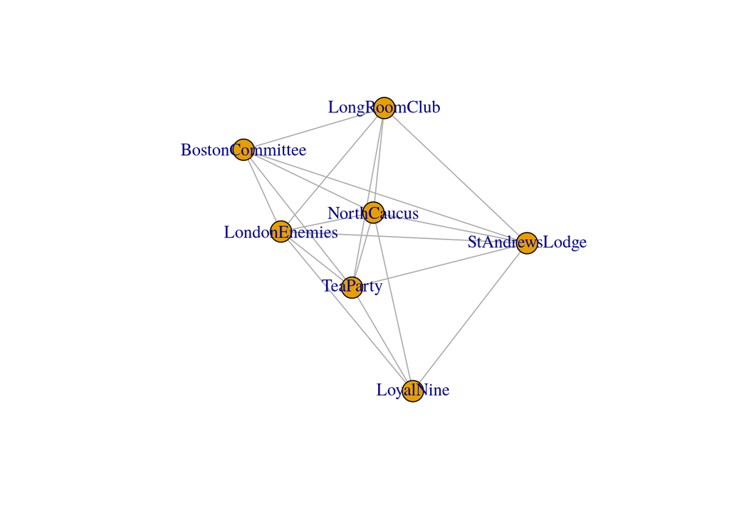

```r
revere_org <- bipartite_projection(revere_bip, which = "true")
plot(revere_org)
```

## In-class assignment

Option 1: Redo some of these analyses using the Field Code code-to-code level data. Try plotting the codes by a centrality measure. Get as close as you can to a presentation graphic.

- `field-codes-edges.csv`
- `field-codes-nodes.csv`

Option 2: Reproduce Kieran Healy’s analysis from this [blog post](https://kieranhealy.org/blog/archives/2013/06/09/using-metadata-to-find-paul-revere/). Use `paul-revere-edges.csv`. Get as close as you can to a presentation graphic.